# Trabajo de intervención grupal

Jose Castañeda Chilon, Jose Joselito Carhuaricra Cusipuma, Joaquín Antonio Castañón Vilca

# Librerías

Las librerías utilizadas son las siguientes:

```r
library(MixAll)
library(MASS)
library(pscl)
library(sandwich)
library(car)
library(lmtest)
```

# Carga de Datos

```r
data(DebTrivedi)
df <- DebTrivedi[, c(1, 6:8, 13, 15, 18)]
str(df)
```

```
#> 'data.frame':    4406 obs. of  7 variables:
#>  $ ofp     : int  5 1 13 16 3 17 9 3 1 0 ...
#>  $ hosp    : int  1 0 3 1 0 0 0 0 0 0 ...
#>  $ health  : Factor w/ 3 levels "poor","average",..: 2 2 1 1 2 1 2 2 2 2 ...
#>   ..- attr(*, "contrasts")= num [1:3, 1:2] 1 0 0 0 0 1
#>   .. ..- attr(*, "dimnames")=List of 2
#>   .. .. ..$ : chr [1:3] "poor" "average" "excellent"
#>   .. .. ..$ : chr [1:2] "poor" "excellent"
#>  $ numchron: int  2 2 4 2 2 5 0 0 0 0 ...
#>  $ gender  : Factor w/ 2 levels "female","male": 2 1 1 2 1 1 1 1 1 1 ...
#>  $ school  : int  6 10 10 3 6 7 8 8 8 8 ...
#>  $ privins : Factor w/ 2 levels "no","yes": 2 2 1 2 2 1 2 2 2 2 ...
```

## Descripción de variables

- **ofp:** como variable dependiente y utilizar las variables de estado de salud, número de visitas al consultorio médico.
- **hosp:** número de estancias hospitalarias.
- **health:** estado de salud autopercibido.
- **numchron:** número de condiciones crónicas.
- Así como las variables socioeconómicas **gender**, **school** (número de años de educación) y **privins** (privado indicador de seguro) como varaibles independientes.

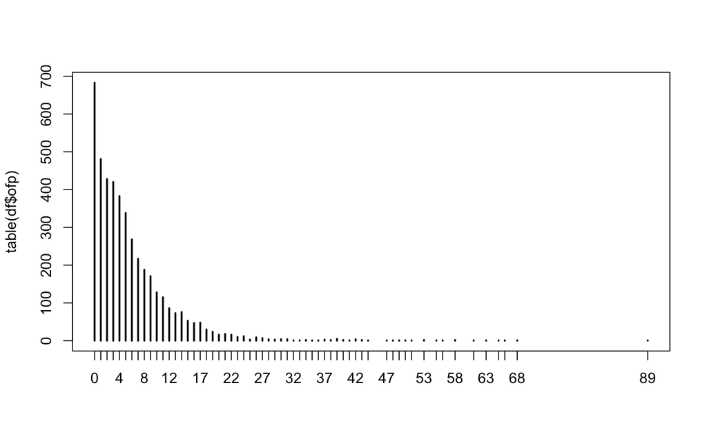

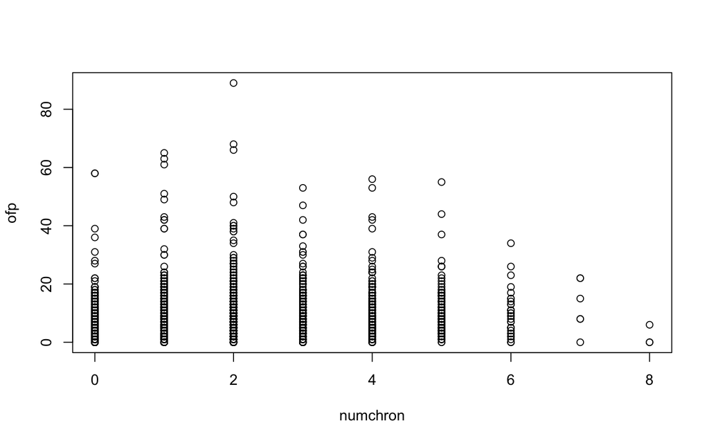

```r
plot(table(df$ofp))
plot(ofp ~ numchron, data = df)
```

Para transformar una variable de conteo en un factor (solo con fines de visualización), definimos otra función de conveniencia cfac ().

```r
clog <- function(x) log(x + 0.5)
cfac <- function(x, breaks = NULL) {
  if(is.null(breaks)) breaks <- unique(quantile(x, 0:10/10))
  x <- cut(x, breaks, include.lowest = TRUE, right = FALSE)
  levels(x) <- paste(breaks[-length(breaks)], ifelse(diff(breaks) > 1,
  c(paste("-", breaks[-c(1, length(breaks))] - 1, sep = ""), "+"), ""),
  sep = "")
  return(x)
}
```

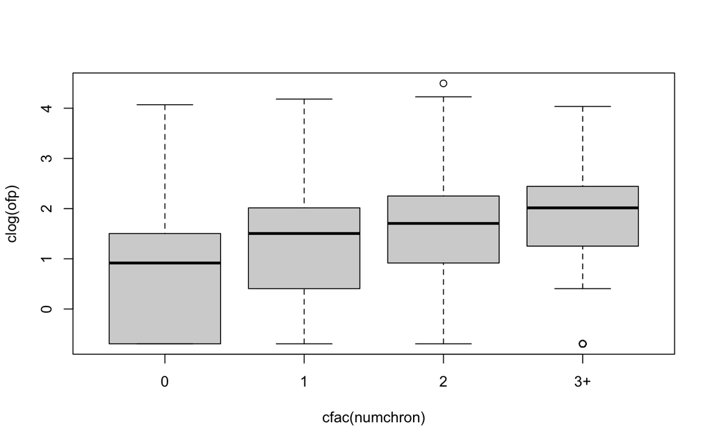

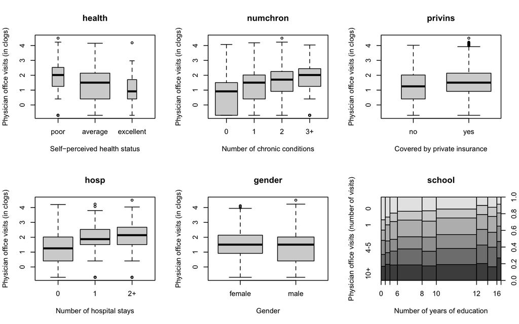

```r
plot(clog(ofp) ~ cfac(numchron), data = df)

par(mfrow = c(2,3))
plot(clog(ofp) ~ health, data = df, varwidth = TRUE, main = 'health', xlab = 'Self−perceived health status', ylab = 'Physician office visits (in clogs)')
plot(clog(ofp) ~ cfac(numchron), data = df, main = 'numchron', xlab = 'Number of chronic conditions', ylab = 'Physician office visits (in clogs)')
plot(clog(ofp) ~ privins, data = df, varwidth = TRUE, main = 'privins', xlab = 'Covered by private insurance', ylab = 'Physician office visits (in clogs)')
plot(clog(ofp) ~ cfac(hosp, c(0:2, 8)), data = df, main = 'hosp',  xlab = 'Number of hospital stays', ylab = 'Physician office visits (in clogs)')
plot(clog(ofp) ~ gender, data = df, varwidth = TRUE, main = 'gender', xlab = 'Gender', ylab = 'Physician office visits (in clogs)')
plot(cfac(ofp, c(0:2, 4, 6, 10, 100)) ~ school, data = df, breaks = 9, main = 'school', xlab = 'Number of years of education', ylab = 'Physician office visits (number of visits)')
```

# Preguntas

## Explicación del Problema de Hurdle

Al igual que el modelo de regresión para datos de conteo cero-inflado, el modelo Hurdle asume la presencia de una mezcla de distribuciones, sólo que dicho modelo tiene una interpretación en dos partes. La primera se refiere a un modelo con variable de respuesta binaria y la segunda a un modelo de datos de conteo truncado-en-cero. En consecuencia, esta configuración en dos partes permite la interpretación de que los valores positivos se generan toda vez que el umbral (Hurdle) en cero se ha cruzado. Por consiguiente, la primera parte modela la probabilidad de que el umbral sea cruzado, mientras que la segunda modela el valor esperado de los valores positivos (Salinas-Rodríguez, Manrique-Espinoza, & Sosa-Rubí, 2009).

## Explicación del Problema de Zero-inflated models

Los modelos inflados cero son otra clase de modelo capaz de tratar con un exceso de recuentos de cero. Son modelos de mezcla de dos componentes que combinan una masa puntual en cero con una distribución de conteo tal como Poisson, binomio geométrico o negativo. Por tanto, hay dos fuentes de ceros: los ceros pueden provienen tanto de la masa puntual como del componente de recuento. Para modelar lo no observado estado (cero frente a cuenta), se utiliza un modelo binario: en el caso más simple, solo con una intersección pero potencialmente conteniendo regresores (Zeileis, Kleiber, & Jackman, 2008).

## Replicación e interpretación de resultados

### Modelo de Hurdle

A continuación se muestran los resultados obtenidos después de replicar el código del paper, para el modelo de Hurdle.

El análisis exploratorio transmitió la impresión de que podría haber más observaciones cero que las explicadas por las distribuciones de datos de conteo básico, por lo tanto, se ajusta un modelo de obstáculo binomial negativo mediante

```r
hurdle_model1 <- hurdle(ofp ~ ., data = df, dist = "negbin")
```

```r
summary(hurdle_model1)
```

```
#>
#> Call:
#> hurdle(formula = ofp ~ ., data = df, dist = "negbin")
#>
#> Pearson residuals:
#>     Min      1Q  Median      3Q     Max
#> -1.1718 -0.7080 -0.2737  0.3196 18.0092
#>
#> Count model coefficients (truncated negbin with log link):
#>                  Estimate Std. Error z value Pr(>|z|)
#> (Intercept)      1.197699   0.058973  20.309  < 2e-16 ***
#> hosp             0.211898   0.021396   9.904  < 2e-16 ***
#> healthpoor       0.315958   0.048056   6.575 4.87e-11 ***
#> healthexcellent -0.331861   0.066093  -5.021 5.14e-07 ***
#> numchron         0.126421   0.012452  10.152  < 2e-16 ***
#> gendermale      -0.068317   0.032416  -2.108   0.0351 *
#> school           0.020693   0.004535   4.563 5.04e-06 ***
#> privinsyes       0.100172   0.042619   2.350   0.0188 *
#> Log(theta)       0.333255   0.042754   7.795 6.46e-15 ***
#> Zero hurdle model coefficients (binomial with logit link):
#>                  Estimate Std. Error z value Pr(>|z|)
#> (Intercept)      0.043147   0.139852   0.309 0.757688
#> hosp             0.312449   0.091437   3.417 0.000633 ***
#> healthpoor      -0.008716   0.161024  -0.054 0.956833
#> healthexcellent -0.289570   0.142682  -2.029 0.042409 *
#> numchron         0.535213   0.045378  11.794  < 2e-16 ***
#> gendermale      -0.415658   0.087608  -4.745 2.09e-06 ***
#> school           0.058541   0.011989   4.883 1.05e-06 ***
#> privinsyes       0.747120   0.100880   7.406 1.30e-13 ***
#> ---
#> Signif. codes:  0 '***' 0.001 '**' 0.01 '*' 0.05 '.' 0.1 ' ' 1
#>
#> Theta: count = 1.3955
#> Number of iterations in BFGS optimization: 16
#> Log-likelihood: -1.209e+04 on 17 Df
```

Para probar esta hipótesis, el modelo reducido se ajusta mediante:

```r
hurdle_model2 <- hurdle(ofp ~ . | hosp + numchron + privins + school + gender, data = df, dist = "negbin")
```

```r
summary(hurdle_model2)
```

```
#>
#> Call:
#> hurdle(formula = ofp ~ . | hosp + numchron + privins + school + gender,
#>     data = df, dist = "negbin")
#>
#> Pearson residuals:
#>     Min      1Q  Median      3Q     Max
#> -1.1719 -0.7089 -0.2733  0.3229 17.9185
#>
#> Count model coefficients (truncated negbin with log link):
#>                  Estimate Std. Error z value Pr(>|z|)
#> (Intercept)      1.197699   0.058973  20.309  < 2e-16 ***
#> hosp             0.211898   0.021396   9.904  < 2e-16 ***
#> healthpoor       0.315958   0.048056   6.575 4.87e-11 ***
#> healthexcellent -0.331861   0.066093  -5.021 5.14e-07 ***
#> numchron         0.126421   0.012452  10.152  < 2e-16 ***
#> gendermale      -0.068317   0.032416  -2.108   0.0351 *
#> school           0.020693   0.004535   4.563 5.04e-06 ***
#> privinsyes       0.100172   0.042619   2.350   0.0188 *
#> Log(theta)       0.333255   0.042754   7.795 6.46e-15 ***
#> Zero hurdle model coefficients (binomial with logit link):
#>             Estimate Std. Error z value Pr(>|z|)
#> (Intercept)  0.01594    0.13776   0.116 0.907881
#> hosp         0.31843    0.09107   3.496 0.000471 ***
#> numchron     0.54783    0.04358  12.571  < 2e-16 ***
#> privinsyes   0.74572    0.10031   7.434 1.05e-13 ***
#> school       0.05707    0.01193   4.785 1.71e-06 ***
#> gendermale  -0.41915    0.08751  -4.790 1.67e-06 ***
#> ---
#> Signif. codes:  0 '***' 0.001 '**' 0.01 '*' 0.05 '.' 0.1 ' ' 1
#>
#> Theta: count = 1.3955
#> Number of iterations in BFGS optimization: 16
#> Log-likelihood: -1.209e+04 on 15 Df
```

Para ambos la prueba de hipotesis es la sigueinte:

```r
waldtest(hurdle_model1, hurdle_model2)
```

```
#> Wald test
#>
#> Model 1: ofp ~ .
#> Model 2: ofp ~ . | hosp + numchron + privins + school + gender
#>   Res.Df Df  Chisq Pr(>Chisq)
#> 1   4389
#> 2   4391 -2 4.1213     0.1274
```

```r
lrtest(hurdle_model1, hurdle_model2)
```

```
#> Likelihood ratio test
#>
#> Model 1: ofp ~ .
#> Model 2: ofp ~ . | hosp + numchron + privins + school + gender
#>   #Df LogLik Df  Chisq Pr(>Chisq)
#> 1  17 -12088
#> 2  15 -12090 -2 3.9875     0.1362
```

Lo que se muestra que los resultados son virtualmente identicos. Dado que para ambas pruebas el valor de p es mayor a 0.05.

### Modelo de Zero-inflated models

A continuación se muestran los resultados obtenidos después de replicar el código del paper, para el modelo de Zero-inflated models:

```r
zinb_reg1 <- zeroinfl(ofp ~ ., data = df, dist = "negbin")
zinb_reg2 <- zeroinfl(ofp ~ . | hosp + numchron + privins + school + gender, data = df, dist = "negbin")
```

```r
waldtest(zinb_reg1, zinb_reg2)
```

```
#> Wald test
#>
#> Model 1: ofp ~ .
#> Model 2: ofp ~ . | hosp + numchron + privins + school + gender
#>   Res.Df Df  Chisq Pr(>Chisq)
#> 1   4389
#> 2   4391 -2 0.1584     0.9239
```

```r
lrtest(zinb_reg1, zinb_reg2)
```

```
#> Likelihood ratio test
#>
#> Model 1: ofp ~ .
#> Model 2: ofp ~ . | hosp + numchron + privins + school + gender
#>   #Df LogLik Df  Chisq Pr(>Chisq)
#> 1  17 -12091
#> 2  15 -12091 -2 0.1525     0.9266
```

```r
summary(zinb_reg2)
```

```
#>
#> Call:
#> zeroinfl(formula = ofp ~ . | hosp + numchron + privins + school + gender,
#>     data = df, dist = "negbin")
#>
#> Pearson residuals:
#>     Min      1Q  Median      3Q     Max
#> -1.1963 -0.7105 -0.2779  0.3253 17.8451
#>
#> Count model coefficients (negbin with log link):
#>                  Estimate Std. Error z value Pr(>|z|)
#> (Intercept)      1.193716   0.056661  21.068  < 2e-16 ***
#> hosp             0.201477   0.020360   9.896  < 2e-16 ***
#> healthpoor       0.285133   0.045093   6.323 2.56e-10 ***
#> healthexcellent -0.319336   0.060405  -5.287 1.25e-07 ***
#> numchron         0.128999   0.011930  10.813  < 2e-16 ***
#> gendermale      -0.080276   0.031024  -2.588  0.00967 **
#> school           0.021424   0.004358   4.916 8.81e-07 ***
#> privinsyes       0.125861   0.041587   3.026  0.00247 **
#> Log(theta)       0.394148   0.035035  11.250  < 2e-16 ***
#>
#> Zero-inflation model coefficients (binomial with logit link):
#>             Estimate Std. Error z value Pr(>|z|)
#> (Intercept) -0.04692    0.26855  -0.175  0.86131
#> hosp        -0.80048    0.42081  -1.902  0.05714 .
#> numchron    -1.24790    0.17830  -6.999 2.58e-12 ***
#> privinsyes  -1.17562    0.22012  -5.341 9.25e-08 ***
#> school      -0.08377    0.02625  -3.191  0.00142 **
#> gendermale   0.64769    0.20011   3.237  0.00121 **
#> ---
#> Signif. codes:  0 '***' 0.001 '**' 0.01 '*' 0.05 '.' 0.1 ' ' 1
#>
#> Theta = 1.4831
#> Number of iterations in BFGS optimization: 26
#> Log-likelihood: -1.209e+04 on 15 Df
```

### Compraciones entre modelos

A continuación se muestra las comparaciones de los dos modelos presentados en el paper:

```r
fm <- list("Hurdle-NB" = hurdle_model2, "ZINB" = zinb_reg2)
sapply(fm, function(x) coef(x)[1:8])
```

```
#>                         Hurdle-NB        ZINB
#> count_(Intercept)      1.19769892  1.19371596
#> count_hosp             0.21189820  0.20147665
#> count_healthpoor       0.31595757  0.28513296
#> count_healthexcellent -0.33186113 -0.31933605
#> count_numchron         0.12642059  0.12899905
#> count_gendermale      -0.06831702 -0.08027596
#> count_school           0.02069321  0.02142363
#> count_privinsyes       0.10017164  0.12586120
```

```r
cbind(sapply(fm[-1], function(x) sqrt(diag(vcov(x)))[1:8]))
```

```
#>                              ZINB
#> count_(Intercept)     0.056660810
#> count_hosp            0.020359692
#> count_healthpoor      0.045092607
#> count_healthexcellent 0.060404914
#> count_numchron        0.011930497
#> count_gendermale      0.031023982
#> count_school          0.004357567
#> count_privinsyes      0.041587497
```

```r
rbind(logLik = sapply(fm, function(x) round(logLik(x), digits = 0)),
Df = sapply(fm, function(x) attr(logLik(x), "df")))
```

```
#>        Hurdle-NB   ZINB
#> logLik    -12090 -12091
#> Df            15     15
```

```r
round(c("Obs" = sum(df$ofp < 1),
"NB-Hurdle" = sum(predict(hurdle_model2, type = "prob")[,1]),
"ZINB" = sum(predict(zinb_reg2, type = "prob")[,1])))
```

```
#>       Obs NB-Hurdle      ZINB
#>       683       683       709
```

```r
t(sapply(fm[1:2], function(x) round(x$coefficients$zero, digits = 3)))
```

```
#>           (Intercept)   hosp numchron privinsyes school gendermale
#> Hurdle-NB       0.016  0.318    0.548      0.746  0.057     -0.419
#> ZINB           -0.047 -0.800   -1.248     -1.176 -0.084      0.648
```

Para el modelo de vallas, el componente de vallas cero describe la probabilidad de observar un conteo positivo mientras que, para el modelo ZINB, el componente de inflación cero predice la probabilidad de observar un conteo de cero a partir del componente de masa puntual. En general, ambos modelos conducen a los mismos resultados cualitativos y ajustes de modelo muy similares. Quizás el modelo de obstáculos es ligeramente preferible porque tiene una interpretación más agradable: hay un proceso que controla si un paciente ve a un médico o no, y un segundo proceso que determina cuántas visitas al consultorio se realizan.

# Referencias

- Salinas-Rodríguez, A., Manrique-Espinoza, B., & Sosa-Rubí, S. G. (2009). Análisis estadístico para datos de conteo: aplicaciones para el uso de los servicios de salud. *Salud Pública de México*, 51, 397-406.
- Zeileis, A., Kleiber, C., & Jackman, S. (2008). Regression models for count data in R. *Journal of statistical software*, 27(8), 1-25.